# Practica 1

# Técnicas de Agrupación y de Reducción de la Dimensión

## ¿Qué sabemos de los viajeros?

El archivo viajeros.csv muestra los datos de 50.000 viajeros de los que tenemos información diversa como su nacionalidad, su sexo, su edad, y, lo que más nos interesa, la valoración que ofrecen a un conjunto muy amplio de características, como su impresión general (en la columna del mismo nombre) o el alojamiento, entre otras (recogidas bajo el genérico valoración_xxx, donde xxx recoge el atributo concreto valorado).

Debe emitir un informe detallando si existen grupos de turistas homogéneos a partir de la valoración que dan a los distintos servicios, tal y como se ha señalado. Deberá justificar que el análisis puede llevarse a cabo, el número de clusters a emplear, y la solución alcanzada. Se valorará, además de una correcta presentación, la identificación de posibles relaciones de los clusters alcanzados con una o varias características adicionales (pista: piense en la posible concentración de viajeros en los clusters en función de su nacionalidad, de su profesión, de su sexo, edad o renta, o de una combinación de las mismas).

Cargamos las librerías necesarias para realizar el análisis cluster.

```r
set.seed(1234)
require(cluster)
require(fpc)
require(factoextra)
require(dplyr)
library(dendextend)
require(ggrepel)
require(NbClust)
viajeros <- read.csv('viajeros.csv')
summary(viajeros)
```

```
##        X             PAIS_RESID_AGRUP
##  Min.   :     3   Alemania   :11164
##  1st Qu.: 65614   España     : 8594
##  Median :132617   Otros      :16967
##  Mean   :132992   Reino Unido:13275
##  3rd Qu.:199846
##  Max.   :268181
##
##                                            ALOJ_CATEG_1     IMPRESION
##  Extrahoteleros                                  :15416   Min.   :1.000
##  Hoteles - apartahoteles de 4 estrellas          :18482   1st Qu.:4.000
##  Hoteles - apartahoteles de 5 estrellas          : 3117   Median :4.000
##  Hoteles - apartahoteles de hasta 3 estrellas    : 7402   Mean   :4.309
##  Otros tipos de alojamientos                     : 1748   3rd Qu.:5.000
##  Viviendas propias o casas de amigos o familiares: 3835   Max.   :5.000
##                                                           NA's   :7311
##  VALORACION_ALOJ  VALORACION_TRATO_ALOJ VALORACION_GASTRONO_ALOJ
##  Min.   : 1.000   Min.   : 1.000        Min.   : 1.000
##  1st Qu.: 7.000   1st Qu.: 8.000        1st Qu.: 7.000
##  Median : 8.000   Median : 9.000        Median : 8.000
##  Mean   : 7.978   Mean   : 8.292        Mean   : 7.649
##  3rd Qu.: 9.000   3rd Qu.:10.000        3rd Qu.: 9.000
##  Max.   :10.000   Max.   :10.000        Max.   :10.000
##  NA's   :5327     NA's   :8339          NA's   :14446
##  VALORACION_CLIMA VALORACION_ZONAS_BANYO VALORACION_PAISAJES
##  Min.   : 1.000   Min.   : 1.000         Min.   : 1.000
##  1st Qu.: 8.000   1st Qu.: 7.000         1st Qu.: 7.000
##  Median : 9.000   Median : 8.000         Median : 9.000
##  Mean   : 8.517   Mean   : 8.068         Mean   : 8.248
##  3rd Qu.:10.000   3rd Qu.: 9.000         3rd Qu.:10.000
##  Max.   :10.000   Max.   :10.000         Max.   :10.000
##  NA's   :3894     NA's   :7442           NA's   :5901
##  VALORACION_MEDIO_AMBIENTE VALORACION_TRANQUILIDAD VALORACION_LIMPIEZA
##  Min.   : 1.000            Min.   : 1.000          Min.   : 1.00
##  1st Qu.: 7.000            1st Qu.: 7.000          1st Qu.: 7.00
##  Median : 8.000            Median : 8.000          Median : 8.00
##  Mean   : 8.073            Mean   : 8.131          Mean   : 8.04
##  3rd Qu.: 9.000            3rd Qu.: 9.000          3rd Qu.: 9.00
##  Max.   :10.000            Max.   :10.000          Max.   :10.00
##  NA's   :6627              NA's   :5504            NA's   :5088
```

[output cut: 57 more lines]

```
##  Min.   : 1.000          Hombre:25975   Min.   :16.00
##  1st Qu.: 8.000          Mujer :24025   1st Qu.:32.00
##  Median : 9.000                         Median :44.00
##  Mean   : 8.477                         Mean   :44.29
##  3rd Qu.:10.000                         3rd Qu.:55.00
##  Max.   :10.000                         Max.   :99.00
##  NA's   :14194
##                         OCUPACION                 INGRESOS
##  Asalariado cargo medio      :12364   De 24001 a 36000: 7435
##  Jubilado  retirado         : 5780   De 12000 a 24000: 7002
##  Empresario                  : 5234   De 36001 a 48000: 6302
##  Autónomo - profesión liberal: 4995   De 48001 a 60000: 5444
##  Otros trabajadores y obreros: 4576   Más de 84000    : 5435
##  (Other)                     :10878   (Other)         : 5393
##  NA's                        : 6173   NA's            :12989
```

Observamos que tenemos muchos valores perdidos en nuestros datos.

Procederemos a crear un nuevo data frame sin valores perdidos y eliminaremos las variables cualitativas del cual extraeremos una muestra aleatoria simple de 1000 observaciones.

```r
viajerosna <- na.omit(viajeros)
viajerosna <- viajerosna[,4:32]
viajerosna_mas =viajerosna[sample(1:nrow(viajerosna), 1000,replace=FALSE),]
summary(viajerosna_mas)
```

```
##    IMPRESION     VALORACION_ALOJ  VALORACION_TRATO_ALOJ
##  Min.   :1.000   Min.   : 1.000   Min.   : 1.000
##  1st Qu.:4.000   1st Qu.: 7.000   1st Qu.: 7.000
##  Median :4.000   Median : 8.000   Median : 8.000
##  Mean   :4.226   Mean   : 7.856   Mean   : 8.119
##  3rd Qu.:5.000   3rd Qu.: 9.250   3rd Qu.:10.000
##  Max.   :5.000   Max.   :10.000   Max.   :10.000
##  VALORACION_GASTRONO_ALOJ VALORACION_CLIMA VALORACION_ZONAS_BANYO
##  Min.   : 1.000           Min.   : 1.000   Min.   : 1.000
##  1st Qu.: 6.000           1st Qu.: 8.000   1st Qu.: 7.000
##  Median : 8.000           Median : 9.000   Median : 8.000
##  Mean   : 7.389           Mean   : 8.544   Mean   : 8.061
##  3rd Qu.: 9.000           3rd Qu.:10.000   3rd Qu.: 9.250
##  Max.   :10.000           Max.   :10.000   Max.   :10.000
##  VALORACION_PAISAJES VALORACION_MEDIO_AMBIENTE VALORACION_TRANQUILIDAD
##  Min.   : 1.000      Min.   : 1.000            Min.   : 1.000
##  1st Qu.: 7.000      1st Qu.: 7.000            1st Qu.: 7.000
##  Median : 9.000      Median : 8.000            Median : 8.000
##  Mean   : 8.227      Mean   : 8.062            Mean   : 8.092
##  3rd Qu.:10.000      3rd Qu.: 9.000            3rd Qu.:10.000
##  Max.   :10.000      Max.   :10.000            Max.   :10.000
##  VALORACION_LIMPIEZA VALORACION_CALIDAD_RESTAUR
##  Min.   : 1.000      Min.   : 1.000
##  1st Qu.: 7.000      1st Qu.: 7.000
##  Median : 8.000      Median : 8.000
##  Mean   : 7.962      Mean   : 7.627
##  3rd Qu.: 9.000      3rd Qu.: 9.000
##  Max.   :10.000      Max.   :10.000
##  VALORACION_OFERTA_GASTR_LOC VALORACION_TRATO_RESTAUR
##  Min.   : 1.000              Min.   : 1.000
##  1st Qu.: 6.000              1st Qu.: 7.000
##  Median : 8.000              Median : 8.000
##  Mean   : 7.329              Mean   : 7.989
##  3rd Qu.: 9.000              3rd Qu.: 9.000
##  Max.   :10.000              Max.   :10.000
##  VALORACION_PRECIO_RESTAUR VALORACION_CULTURA VALORACION_DEPORTES
##  Min.   : 1.000            Min.   : 1.000     Min.   : 1.000
##  1st Qu.: 7.000            1st Qu.: 6.000     1st Qu.: 6.000
##  Median : 8.000            Median : 7.000     Median : 8.000
##  Mean   : 7.463            Mean   : 7.074     Mean   : 7.307
```

[output cut: 22 more lines]

```
##  Max.   :10.000           Max.   :10.000            Max.   :10.000
##  VALORACION_SEGURIDAD VALORACION_ESTADO_CARRETERAS
##  Min.   : 1.000       Min.   : 1.000
##  1st Qu.: 7.000       1st Qu.: 6.000
##  Median : 8.000       Median : 8.000
##  Mean   : 7.913       Mean   : 7.554
##  3rd Qu.: 9.000       3rd Qu.: 9.000
##  Max.   :10.000       Max.   :10.000
##  VALORACION_CALIDAD_COMERCIO VALORACION_HOSPITALIDAD
##  Min.   : 1.000              Min.   : 1.000
##  1st Qu.: 6.000              1st Qu.: 7.750
##  Median : 8.000              Median : 9.000
##  Mean   : 7.363              Mean   : 8.252
##  3rd Qu.: 9.000              3rd Qu.:10.000
##  Max.   :10.000              Max.   :10.000
```

Calculamos algunos estadisticos:

```r
viajerosna_mas_stats = data.frame(
  Min = apply(viajerosna_mas, 2, min), # mínimo
  Med = apply(viajerosna_mas, 2, median), # mediana
  Mean = apply(viajerosna_mas, 2, mean), # media
  SD = apply(viajerosna_mas, 2, sd), # desviación típica
  Max = apply(viajerosna_mas, 2, max) # máximo
)
viajerosna_mas_stats = round(viajerosna_mas_stats, 1)
head(viajerosna_mas_stats)
```

```
##                          Min Med Mean  SD Max
## IMPRESION                  1   4  4.2 0.9   5
## VALORACION_ALOJ            1   8  7.9 2.0  10
## VALORACION_TRATO_ALOJ      1   8  8.1 2.0  10
## VALORACION_GASTRONO_ALOJ   1   8  7.4 2.3  10
## VALORACION_CLIMA           1   9  8.5 1.6  10
## VALORACION_ZONAS_BANYO     1   8  8.1 1.9  10
```

Observamos que la media de los valores es bastante parecido a su mediana, por lo que se puede tipificar con respecto a la media.

```r
viajeros_tip=scale(viajerosna_mas)
summary(viajeros_tip)
```

```
##    IMPRESION       VALORACION_ALOJ    VALORACION_TRATO_ALOJ
##  Min.   :-3.5806   Min.   :-3.47920   Min.   :-3.59071
##  1st Qu.:-0.2508   1st Qu.:-0.43439   1st Qu.:-0.56441
##  Median :-0.2508   Median : 0.07308   Median :-0.06002
##  Mean   : 0.0000   Mean   : 0.00000   Mean   : 0.00000
##  3rd Qu.: 0.8591   3rd Qu.: 0.70741   3rd Qu.: 0.94875
##  Max.   : 0.8591   Max.   : 1.08801   Max.   : 0.94875
##  VALORACION_GASTRONO_ALOJ VALORACION_CLIMA  VALORACION_ZONAS_BANYO
##  Min.   :-2.7295          Min.   :-4.6179   Min.   :-3.80553
##  1st Qu.:-0.5934          1st Qu.:-0.3330   1st Qu.:-0.57183
##  Median : 0.2610          Median : 0.2791   Median :-0.03288
##  Mean   : 0.0000          Mean   : 0.0000   Mean   : 0.00000
##  3rd Qu.: 0.6882          3rd Qu.: 0.8913   3rd Qu.: 0.64081
##  Max.   : 1.1154          Max.   : 0.8913   Max.   : 1.04503
##  VALORACION_PAISAJES VALORACION_MEDIO_AMBIENTE VALORACION_TRANQUILIDAD
##  Min.   :-4.0333     Min.   :-3.97060          Min.   :-3.7773
##  1st Qu.:-0.6848     1st Qu.:-0.59711          1st Qu.:-0.5816
##  Median : 0.4314     Median :-0.03486          Median :-0.0490
##  Mean   : 0.0000     Mean   : 0.00000          Mean   : 0.0000
##  3rd Qu.: 0.9895     3rd Qu.: 0.52739          3rd Qu.: 1.0162
##  Max.   : 0.9895     Max.   : 1.08964          Max.   : 1.0162
##  VALORACION_LIMPIEZA VALORACION_CALIDAD_RESTAUR
##  Min.   :-3.73093    Min.   :-3.6948
##  1st Qu.:-0.51553    1st Qu.:-0.3496
##  Median : 0.02036    Median : 0.2080
##  Mean   : 0.00000    Mean   : 0.0000
##  3rd Qu.: 0.55626    3rd Qu.: 0.7655
##  Max.   : 1.09216    Max.   : 1.3230
##  VALORACION_OFERTA_GASTR_LOC VALORACION_TRATO_RESTAUR
##  Min.   :-3.1826             Min.   :-4.037878
##  1st Qu.:-0.6683             1st Qu.:-0.571392
##  Median : 0.3374             Median : 0.006355
##  Mean   : 0.0000             Mean   : 0.000000
##  3rd Qu.: 0.8403             3rd Qu.: 0.584103
##  Max.   : 1.3431             Max.   : 1.161850
##  VALORACION_PRECIO_RESTAUR VALORACION_CULTURA VALORACION_DEPORTES
##  Min.   :-3.3865           Min.   :-2.94814   Min.   :-3.2091
##  1st Qu.:-0.2426           1st Qu.:-0.52129   1st Qu.:-0.6650
##  Median : 0.2814           Median :-0.03592   Median : 0.3526
##  Mean   : 0.0000           Mean   : 0.00000   Mean   : 0.0000
```

[output cut: 22 more lines]

```
##  Max.   : 1.1990          Max.   : 1.07231          Max.   : 1.1601
##  VALORACION_SEGURIDAD VALORACION_ESTADO_CARRETERAS
##  Min.   :-3.82132     Min.   :-3.1817
##  1st Qu.:-0.50468     1st Qu.:-0.7544
##  Median : 0.04809     Median : 0.2165
##  Mean   : 0.00000     Mean   : 0.0000
##  3rd Qu.: 0.60086     3rd Qu.: 0.7020
##  Max.   : 1.15364     Max.   : 1.1874
##  VALORACION_CALIDAD_COMERCIO VALORACION_HOSPITALIDAD
##  Min.   :-3.1930             Min.   :-4.1406
##  1st Qu.:-0.6840             1st Qu.:-0.2866
##  Median : 0.3197             Median : 0.4271
##  Mean   : 0.0000             Mean   : 0.0000
##  3rd Qu.: 0.8215             3rd Qu.: 0.9980
##  Max.   : 1.3233             Max.   : 0.9980
```

```r
viajeros_tip_stats = data.frame(
  Min = apply(viajeros_tip, 2, min), # mínimo
  Med = apply(viajeros_tip, 2, median), # mediana
  Mean = apply(viajeros_tip, 2, mean), # media
  SD = apply(viajeros_tip, 2, sd), # desviación típica
  Max = apply(viajeros_tip, 2, max) # máximo
)
viajeros_tip_stats = round(viajeros_tip_stats, 1)
head(viajeros_tip_stats)
```

```
##                           Min  Med Mean SD Max
## IMPRESION                -3.6 -0.3    0  1 0.9
## VALORACION_ALOJ          -3.5  0.1    0  1 1.1
## VALORACION_TRATO_ALOJ    -3.6 -0.1    0  1 0.9
## VALORACION_GASTRONO_ALOJ -2.7  0.3    0  1 1.1
## VALORACION_CLIMA         -4.6  0.3    0  1 0.9
## VALORACION_ZONAS_BANYO   -3.8  0.0    0  1 1.0
```

Calcularemos el dendograma de los datos para ver como se comporta nuestra muestra.

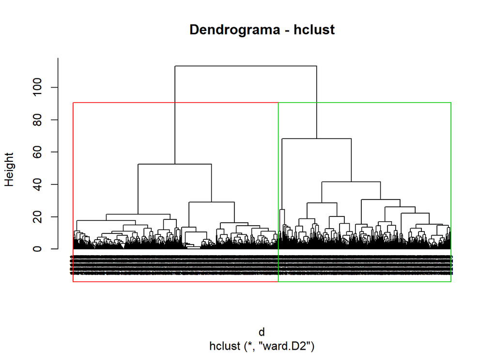

```r
viajeros_tip=as.data.frame(viajeros_tip)
d = dist(viajeros_tip, method = "euclidean")
viajeros.hc = hclust(d, method = "ward.D2" )
plot(viajeros.hc, cex = 0.6, hang = -1, main="Dendrograma - hclust")
rect.hclust(viajeros.hc,k=2,border=2:4)
```

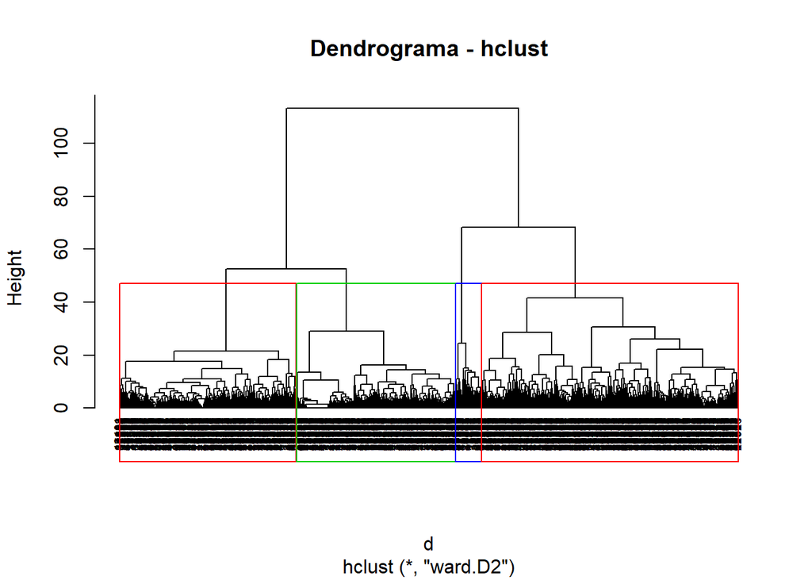

```r
plot(viajeros.hc, cex = 0.6, hang = -1, main="Dendrograma - hclust")
rect.hclust(viajeros.hc,k=4,border=2:4)
```

A simple viste observamos que se podrían hacer 2 o 4 grupos para agrupar a nuestra muestra.

```r
grp = cutree(viajeros.hc, k = 2)
table(grp)
```

```
## grp
##   1   2
## 457 543
```

```r
grp2 = cutree(viajeros.hc, k = 4)
table(grp2)
```

```
## grp2
##   1   2   3   4
## 415 286 257  42
```

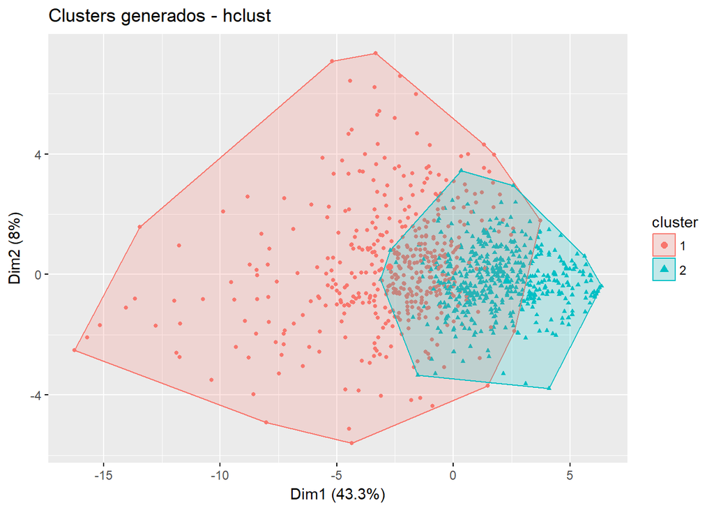

```r
fviz_cluster(list(data = viajeros_tip, cluster = grp), stand = FALSE, geom = "point", pointsize = 1,title="Clusters generados - hclust")
```

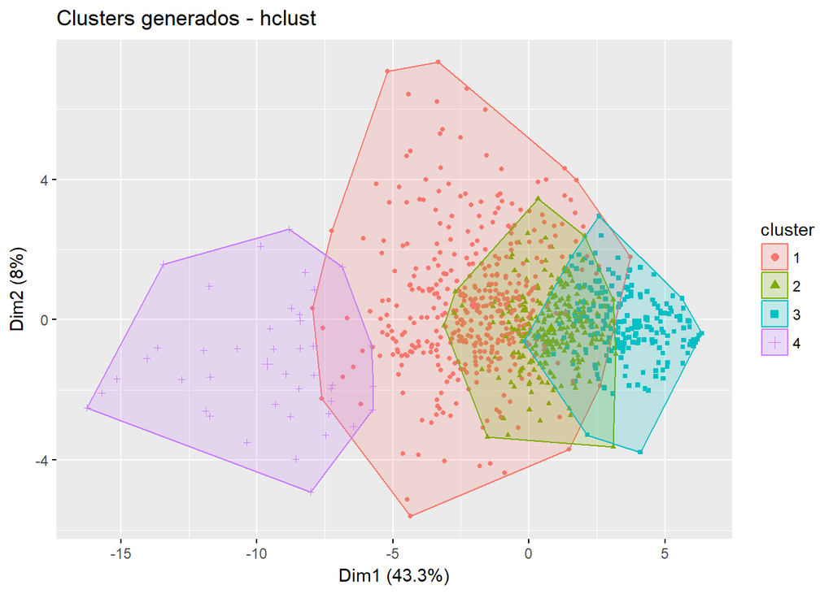

```r
fviz_cluster(list(data = viajeros_tip, cluster = grp2), stand = FALSE, geom = "point", pointsize = 1,title="Clusters generados - hclust")
```

A simple vista no podemos decir cuál de estos dos clusters es mejor.

Ahora realizaremos un análisis para ver cuál es el número óptimo de clusters.

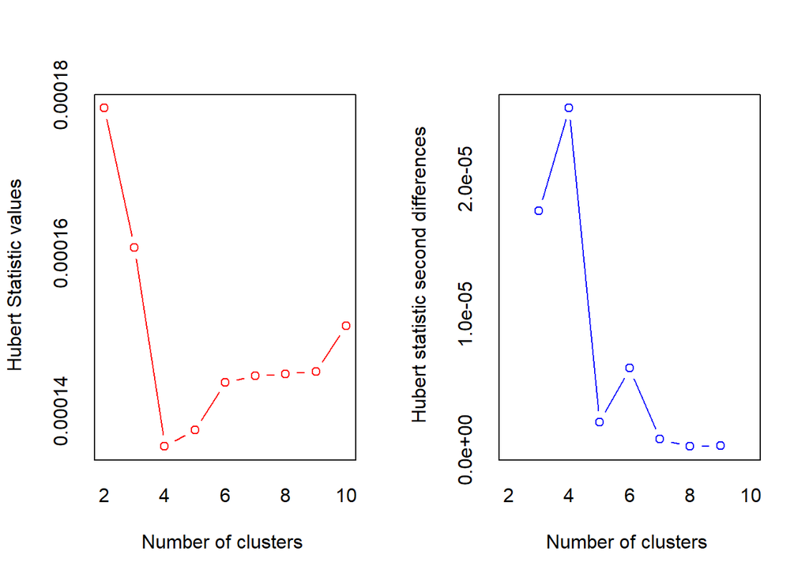

```
## *** : The Hubert index is a graphical method of determining the number of clusters.
##                 In the plot of Hubert index, we seek a significant knee that corresponds to a
##                 significant increase of the value of the measure i.e the significant peak in Hubert
##                 index second differences plot.
##
```

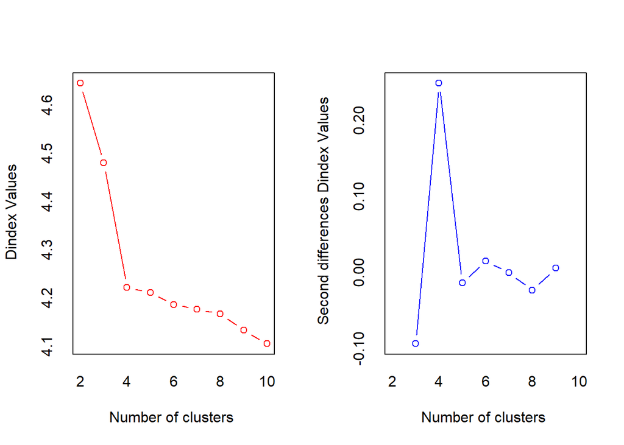

```
## *** : The D index is a graphical method of determining the number of clusters.
##                 In the plot of D index, we seek a significant knee (the significant peak in Dindex
##                 second differences plot) that corresponds to a significant increase of the value of
##                 the measure.
##
## * Among all indices:
## * 8 proposed 2 as the best number of clusters
## * 2 proposed 3 as the best number of clusters
## * 14 proposed 4 as the best number of clusters
##
##                    ***** Conclusion *****
##
## * According to the majority rule, the best number of clusters is  4
##
##
```

```r
Nb.viajeros=NbClust(viajeros_tip, distance = "euclidean", min.nc = 2,
                 max.nc = 10, method = "complete", index ="all")
```

```
## Among all indices:
## ===================
## * 2 proposed  0 as the best number of clusters
## * 8 proposed  2 as the best number of clusters
## * 2 proposed  3 as the best number of clusters
## * 14 proposed  4 as the best number of clusters
##
## Conclusion
## =========================
## * According to the majority rule, the best number of clusters is  4 .
```

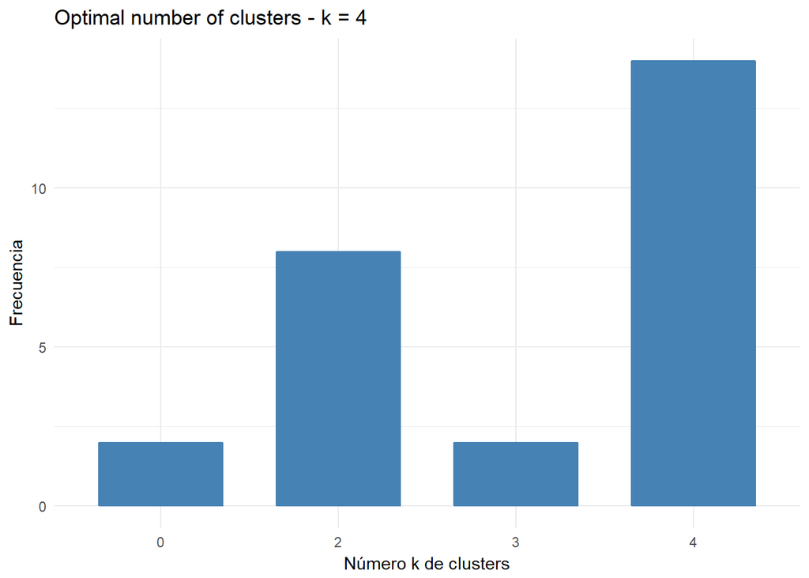

```r
fviz_nbclust(Nb.viajeros) + theme_minimal() +
  labs(x="Número k de clusters", y="Frecuencia")
```

Podemos observar que el número óptimo de clusters son 4 pero parece que 2 también serpia una buena opción para partir nuestros datos. Haremos dos clusters, uno con dos particiones y otro con 4 y veremos cual se comporta mejor.

Utilizaremos el método CLARA para obtener nuestros clusters finales.

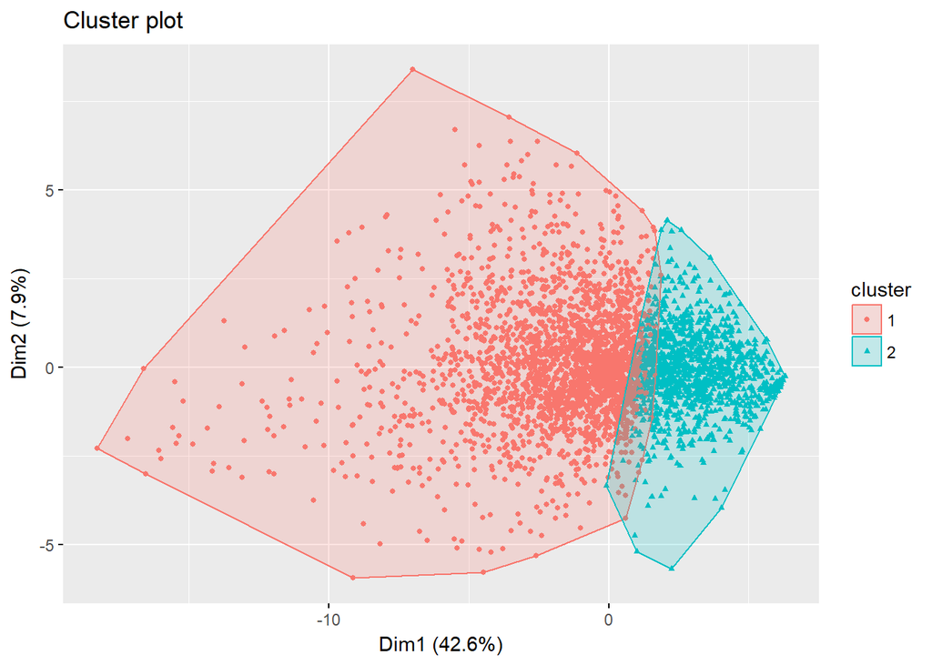

```r
viajeros.clara=clara(viajerosna, 2, samples=200)
fviz_cluster(viajeros.clara, stand = TRUE, geom = "point", pointsize = 1)
```

En este gráfico se observa que se separan bastante bien las observaciones.

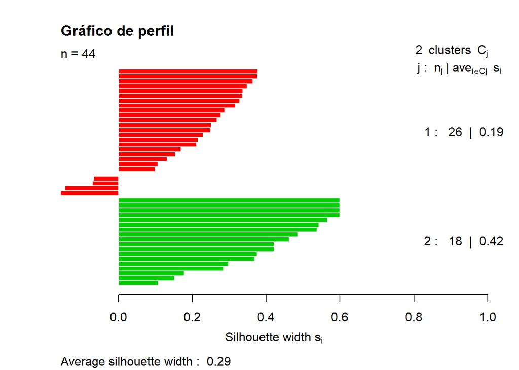

```r
plot(silhouette(viajeros.clara), col = 2:3, main = "Gráfico de perfil")
```

```
##   cluster size ave.sil.width
## 1       1   26          0.19
## 2       2   18          0.42
```

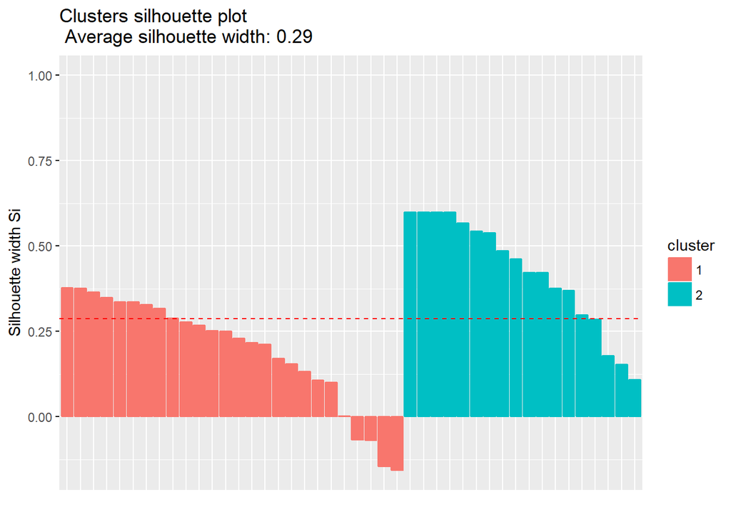

```r
fviz_silhouette(silhouette(viajeros.clara))
```

Vemos que el grupo 2 en su mayoría está bien clasificado pero el grupo 1 no tanto.

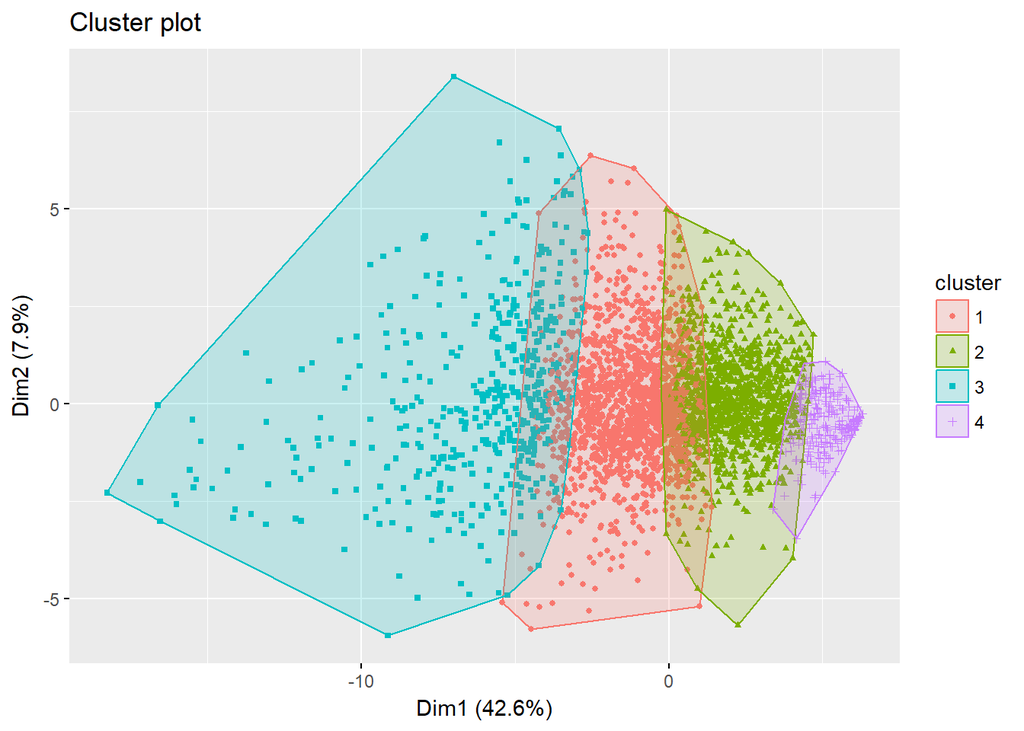

```r
viajeros.clara=clara(viajerosna, 4, samples=200)
fviz_cluster(viajeros.clara, stand = TRUE, geom = "point", pointsize = 1)
```

Con 4 grupos también se ve que es una buena clasificación pero algunos grupos están muy por encimas de otros. Se puede notar que con las dos dimensiones de nuestro gráfico se explica el 50% de la muestra lo cual está bastante bien.

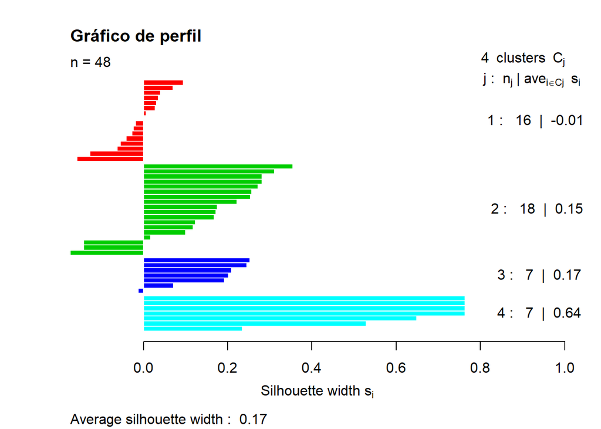

```r
plot(silhouette(viajeros.clara), col = 2:5, main = "Gráfico de perfil")
```

```
##   cluster size ave.sil.width
## 1       1   16         -0.01
## 2       2   18          0.15
## 3       3    7          0.17
## 4       4    7          0.64
```

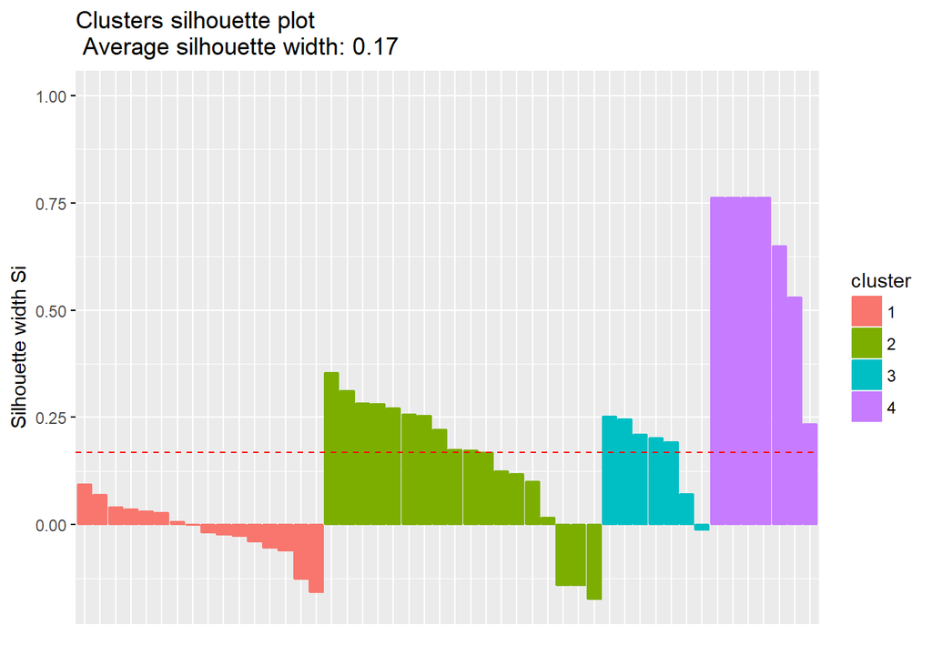

```r
fviz_silhouette(silhouette(viajeros.clara))
```

El grupo 1 está mal calificado pero los demas grupos en general se ven bien.

Nos quedaremos con el cluster de 4 grupos ya que el test nos dice que este es el que clasifica mejor a la muestra.

```r
clusters<-viajeros.clara$clustering
clusters<-as.data.frame(clusters)
resultado<-na.omit(viajeros)
resultado<-data.frame(resultado,clusters)
```

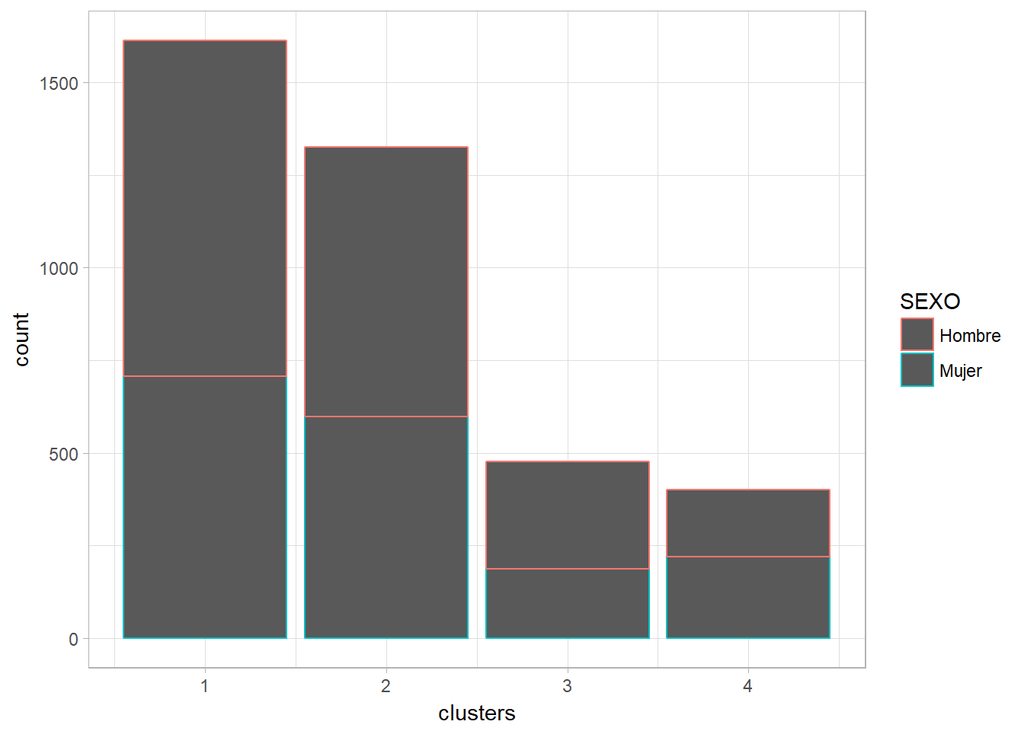

```r
ggplot(data=resultado)+geom_bar(aes(x=clusters,color=SEXO))+ theme_light()
```

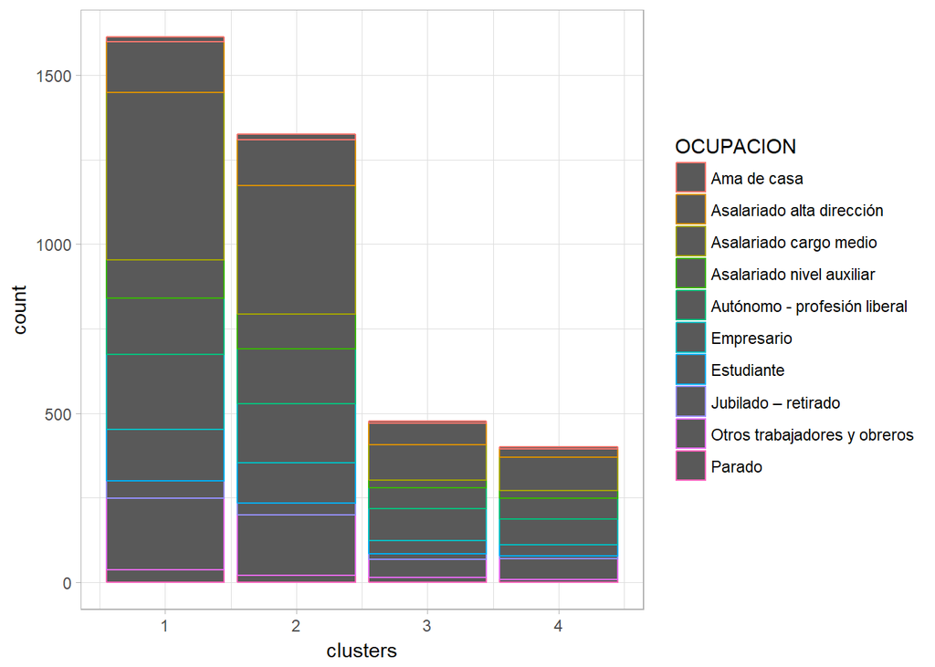

```r
ggplot(data=resultado)+geom_bar(aes(x=clusters,color=OCUPACION))+ theme_light()
```

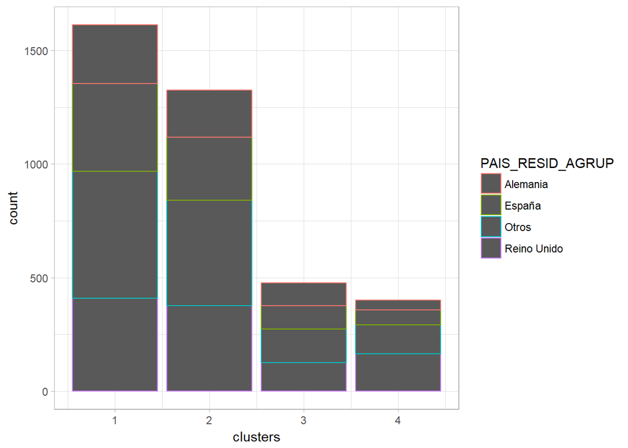

```r
ggplot(data=resultado)+geom_bar(aes(x=clusters,color=PAIS_RESID_AGRUP))+ theme_light()
```

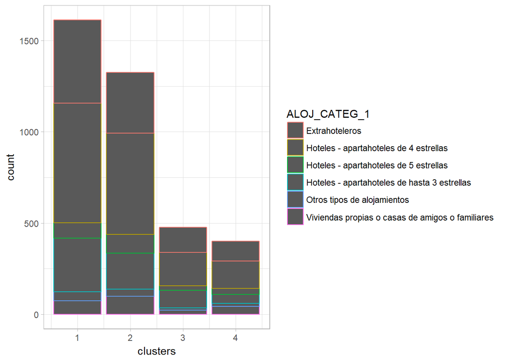

```r
ggplot(data=resultado)+geom_bar(aes(x=clusters,color=ALOJ_CATEG_1))+ theme_light()
```

En este gráfico se ve que en los grupos 3 y 4 hay pocas personas que se quedaron en viviendas propias o casas de amigos o familiares.

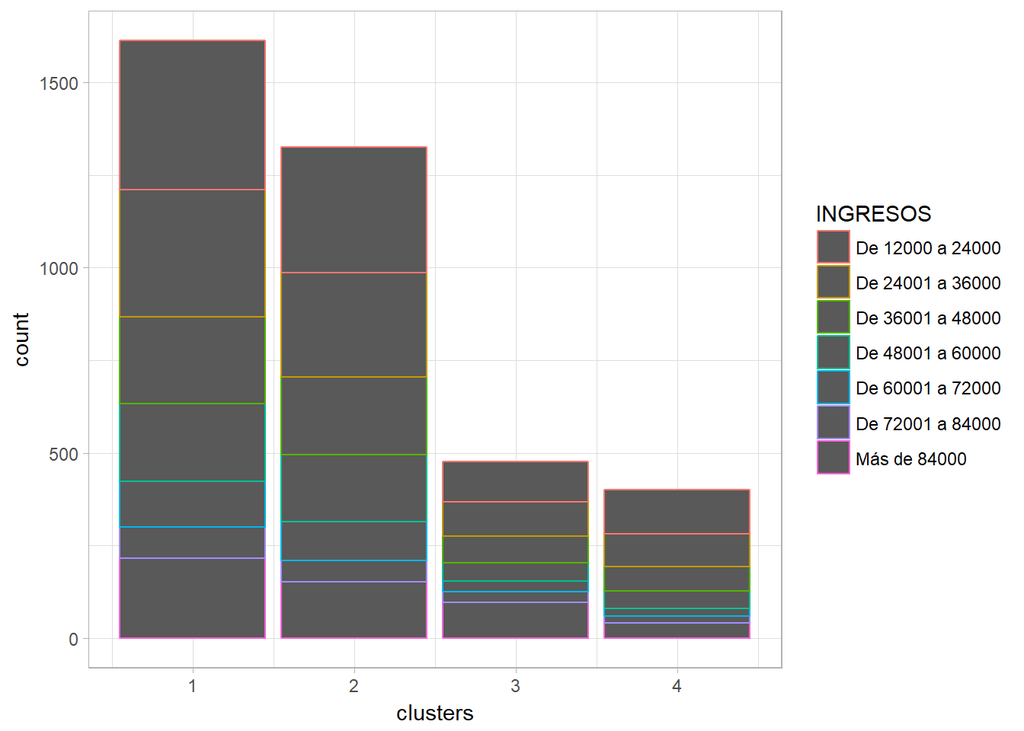

```r
ggplot(data=resultado)+geom_bar(aes(x=clusters,color=INGRESOS))+ theme_light()
```

Comparaciones entre cluster sobre la impresión y valoración del alojamiento:

```r
table(resultado$clusters,resultado$IMPRESION)
```

```
##
##        1    2    3    4    5
##   1   39   44  108 1000  421
##   2   27    9   15  384  891
##   3   11   33  134  246   52
##   4   17    0    4   28  351
```

```r
table(resultado$clusters,resultado$VALORACION_ALOJ)
```

```
##
##       1   2   3   4   5   6   7   8   9  10
##   1  11  16  24  40 102 168 344 483 248 176
##   2   7   1   5   3  22  41  92 391 342 422
##   3  21  22  37  42  73  61  81  68  32  39
##   4   0   0   0   1   2   2   6  23  37 329
```